# Question 5

Abstract

Appalling Designs pitch for a new app based on past experaince

# Introduction

Using Google play and user reports to compile an analysis on there being new app for AppallingDesigns

# APPs

For the apps i will be looking at a few points

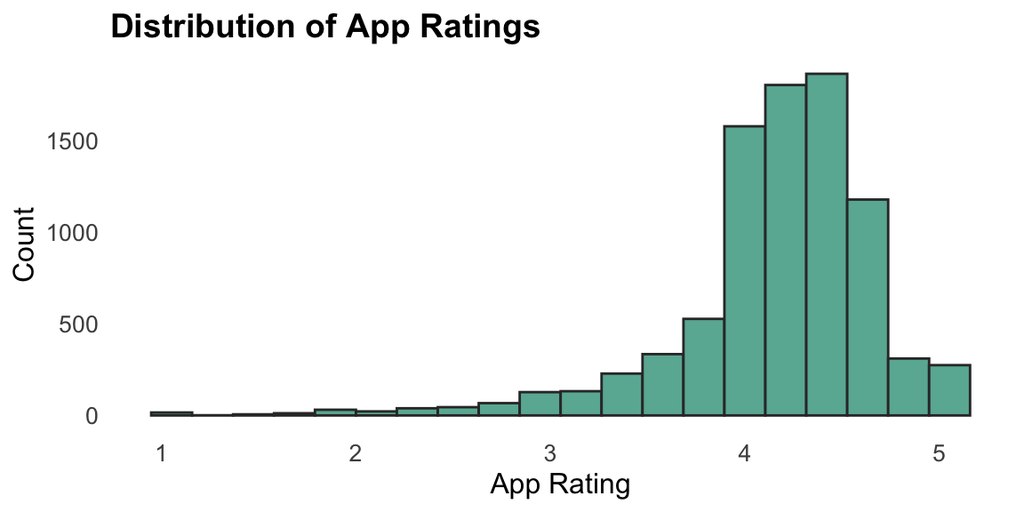

APP ratings

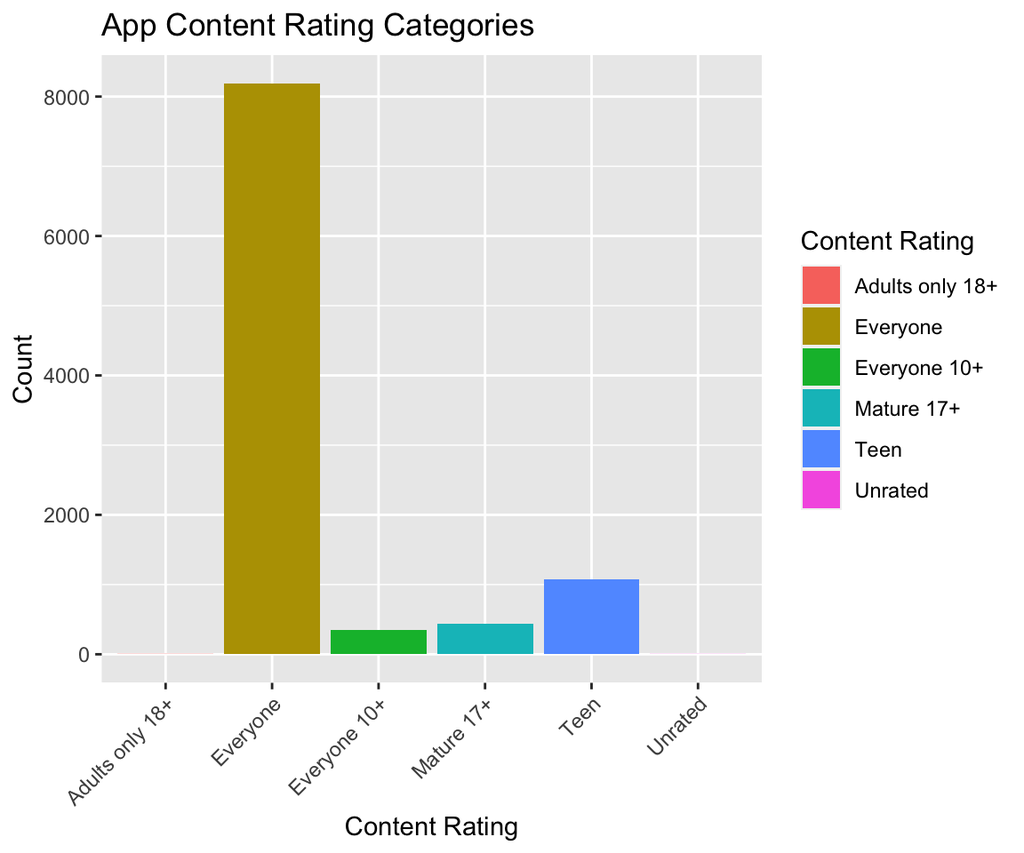

CONTENT

## App ratings

Important considerations to look at is that apps must be contentiously updated as users want the new and best features all the time.

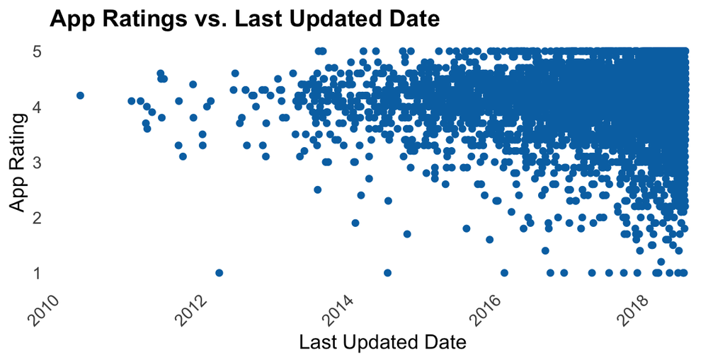

Ratings to update

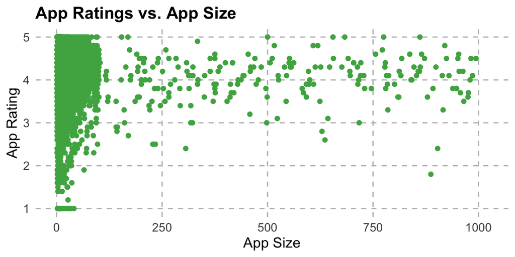

Rating to Size

# User Feedback

It is vital that we get feedback from the user to ensure that we are meeting there demands in an ever changing world.

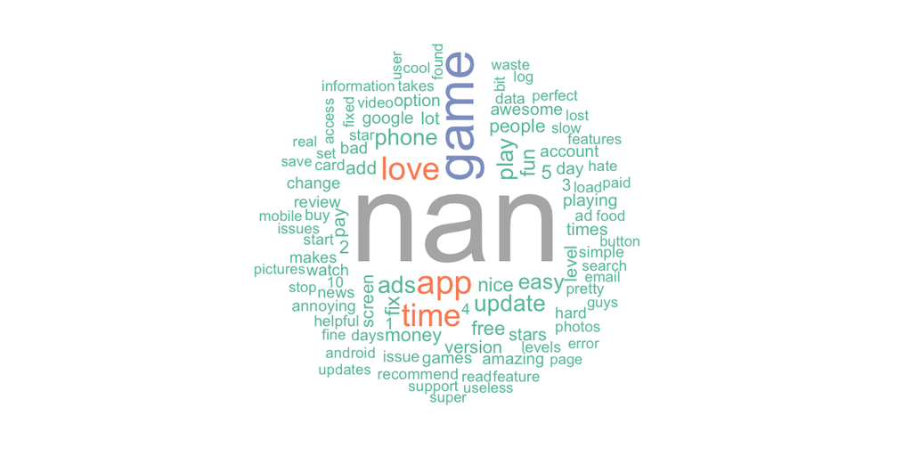

User Reviews

As we can see that the most common response is that users tend not to answer this question. It would be vital to ensure that we get feedback from them.

[figure not shown]

App Sentiment

Looking at some of the apps it is important to ensure that users have a great opion of the app as the app can be spread through good word of mouth.

# Conclusion

Therefore for Appalling Designs to design an app it must ensure that the app is for everyone that way it can have a bigger reach. That is regularly updated to keeps up with the changing demand, this will ensure that user will have a great sentiment towards the app.